# mjfrigaard

[output not shown]

[figure not shown]

### Shiny, {R6}, and R Packages

As Shiny applications grow, organizing code into modular, object-oriented pieces becomes crucial. While Shiny’s reactive programming model is naturally functional, `R6` classes…

Jul 25, 2026

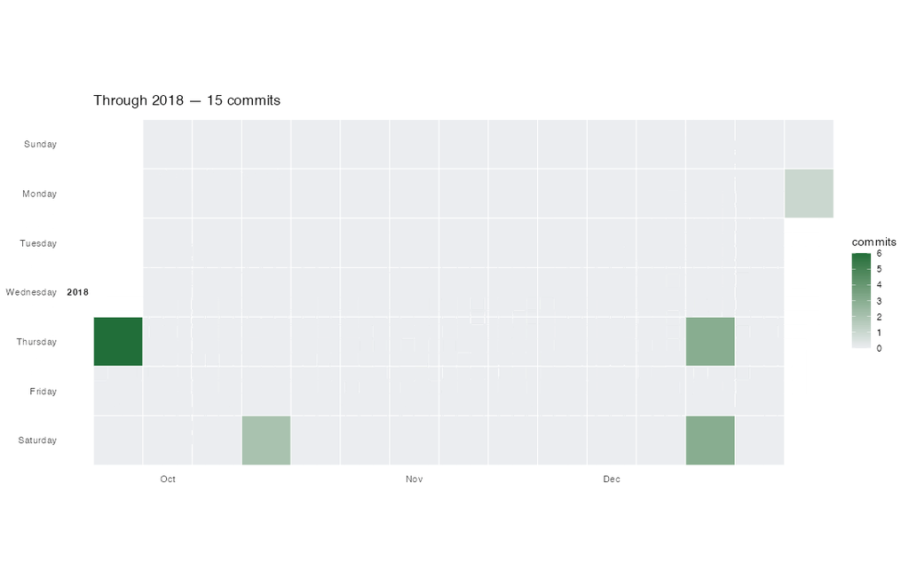

### Create GitHub README with R Markdown

GitHub `README` files allow users to introduce themselves, share interests, projects, status, etc.<sup>1</sup> I love working in RMarkdown, so I wrote a small package that allows me to…

Jun 29, 2026

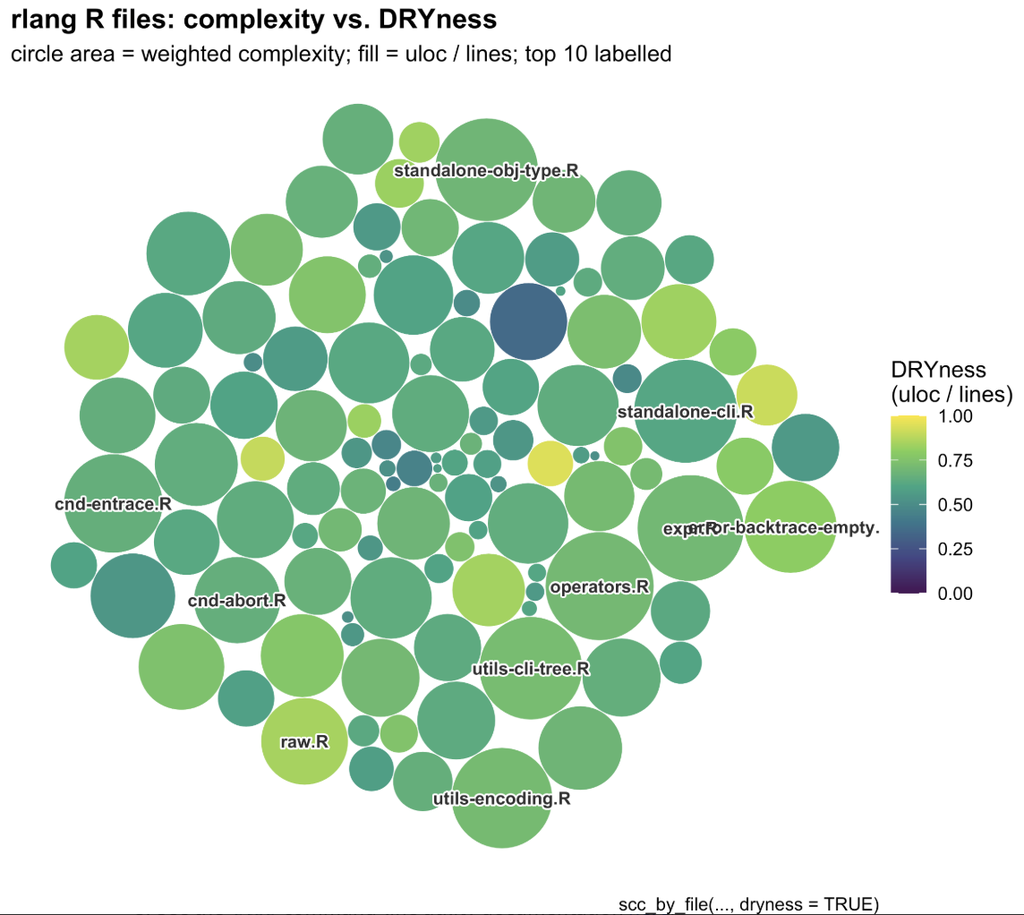

### glockr: An R Wrapper around Succinct Code Counter

Last week I built `glockr`, an R package that wraps scc, a “*very fast accurate code counter with complexity calculations.*” Code metrics are a fascination of mine, and now that…

May 24, 2026

[figure not shown]

### Who is this for?

I’ve written and discarded several drafts of this post out of concern that they sounded overly alarmist. For this version, I chose to step back from the technical details of…

Mar 28, 2026

[figure not shown]

### Posit on Pop!_OS

I recently purchased a System76 laptop, which comes with Pop!_OS, an Ubuntu-flavored operating system. This post covers installing R, Python, and Quarto and setting up…

Mar 8, 2026

[figure not shown]

### plumber vs **`plumber2`**

I’ve been working through the exercises in Alex K Gold’s DevOps for Data Science and this week I finished the API labs. When the book was written, `plumber2` hadn’t been…

Dec 17, 2025

[figure not shown]

### Shiny (for Python) & APIs

This is the second post demonstrating how to use Shiny apps with a database and an API (see previous post here). Both of these solutions are inspired by the exercises in the …

Jul 21, 2025

[figure not shown]

### Quarto Shiny Apps in R Packages

This post was prompted by a new chapter I’ve been working on for Shiny App-Packages. I’ve recently been building a Shiny application in a Quarto document<sup>1</sup>, and noticed quite…

Feb 6, 2025


### Positron

I’ve been trying out Posit’s new Positron IDE for a few weeks, so I put together a post covering my initial impressions of developing Shiny apps and R packages.

Oct 14, 2024

[figure not shown]

### Python Apps

This is the second post on working in VS Code with Python. I’ll cover developing and publishing Python applications using Bokeh, Streamlit, and Dash.

Jul 13, 2024

[figure not shown]

### VS Code, meet Quarto.

I’ve been using VS Code to write more and more Python code lately, so I’ve decided make some notes on 1) installing Python, 2) working in VS Code, and 3) using Python code…

Jul 5, 2024

[figure not shown]

### Shiny system tests with `shinytest2`

This post has been shortened from the original version. I felt it was too long and duplicative of other resources written better elsewhere. If you’d like to read the…

Oct 15, 2023

[figure not shown]

### Testing Shiny modules

This is the third post in a series on testing shiny applications. I’ll cover testing shiny module server functions using the `testhat` package and shiny’s `testServer()` function.

Oct 1, 2023

[figure not shown]

### Debugging in RStudio

In this post I’ll cover using the `browser()` function with RStudio’s debugger. RStudio’s debugging tools are built into the IDE, which provides a seamless transition between…

Sep 1, 2023

[figure not shown]

### Testing Non-Package Shiny Apps

This is the second post in a series on testing Shiny applications. I’ll cover testing Shiny module server functions using the `testhat` package *outside* of an R package…

Aug 20, 2023

[figure not shown]

### Behavior Driven Unit Tests

This post is the first in a series on testing Shiny applications. We’ll cover developing and testing a set of utility functions for a Shiny app-package using `testhat`. If…

Aug 1, 2023

[figure not shown]

### Writing modular code with `box`

`box` provides a precise and concise method for using add-on packages and functions. `box` also doesn’t require bundling your code into R packages to make it reusable. This post…

Jun 21, 2023

[figure not shown]

### purrr updates (v1.0.0)

This post is going to cover the recent updates to the `purrr` package. The release of version 1.0.0 (and dev version v1.0.1) had some breaking changes, which I will cover…

Feb 5, 2023

[interactive chart not shown]